# Assignment 5

JUFENG_YANG

2022-10-26

# *** Prepare: Load packages ***

Some of the questions in this assignment require the tidyverse package. If it hasn’t been installed on your computer, please use install.packages() to install them first. To road the tidyverse package:

```r
library(tidyverse)
```

# *1. Conditional probability, Bayes rule and independence*

### *1.1 Bayes theorem*

#### **1.1 Q1**

$$
$$\begin{aligned}
P(B) &= P(B|A) * P(A) + P(B|A^c) * P(A^c) \\
&= P(B|A) * P(A) + (1 - P(B^c|A^c)) * (1 - P(A)) \\
&= 0.8 * 0.9 + 0.25 * 0.1 \\
&= 0.745
\end{aligned}$$

So, It is easy to get:

$$P(A|B) = \frac{P(A)\ P(B|A))}{P(B)} = \frac{0.9*0.8}{0.745} = 0.9665$$
#### **1.2 Q1**

$$
$$\begin{aligned}
&1. \qquad \qquad && P(A|B) = \frac{P(A\cap B)}{P(B)} =
\frac{P(A)}{P{B}} \quad Because\ of\ A\subseteq B \\[2ex]
&&&if \ P(B\setminus A) = \emptyset \ \Rightarrow \ P(A|B)
= 1 \\[7ex]
&2. \qquad \qquad &&P(A|B) = \frac{P(A \cap B)}{P(B)} =
\frac{P(\emptyset)}{P(B)} = 0 \\[2ex]
&&& P(A \cap B) = 0. \quad P(A|B) = 0 \\[7ex]
&3. \qquad \qquad &&P(A|B) = \frac{P(A \cap B)}{P(B)} =
\frac{P(B)}{P{B}} = 1 \\[7ex]
&4. \qquad \qquad &&P(A|\Omega) = \frac{P(A \cap
\Omega)}{P(\Omega)} = \frac{P(A)}{P(\Omega)} \\[7ex]
&5. \qquad \qquad &&P(A|B \cap C) = \frac{P(A \cap B \cap
C)}{P(B \cap C)} \qquad \qquad (1)\\[2ex]
&&& P(B \cap C) = P(B|C) * P(C) \qquad \qquad (2)\\[2ex]
&&& Conbine \ two \ eqationa \ (1) \ and \ (2): \\[2ex]
&&& \Rightarrow P(A \cap B \cap C) = P(A|B \cap C) * P(B|C)
* P(C) \\[7ex]
&6. \qquad \qquad &&P(A \cap B \cap C) = P(A|B \cap C) * P(B
\cap C) \qquad \qquad (3) \\[2ex]
&&& P(A \cap B \cap C) = P(B|A \cap C) * P(A \cap C) \qquad
\qquad (4) \\[2ex]
&&& P(B \cap C) = P(B \cap C) * P(C) \qquad \qquad (5)
\\[2ex]
&&& P(A \cap C) = P(A | C) * P(C) \qquad \qquad (6) \\[2ex]
&&& Conbine\ (3) \ and \ (4): \\[2ex]
&&& \Rightarrow P(A | B \cap C) * P(B \cap C) = P(B | A \cap
C) * P(A \cap C) \qquad \qquad (7) \\[2ex]
&&& Conbine\ (5) \ ,(6) \ , (7): \\[2ex]
&&& P(A | B \cap C) = \frac{P(B|A \cap C) * P(A |
C)}{P(B|C)}
\end{aligned}$$

#### **1.2 Q2**

Let windy weather as event A, flight is cancelled as event B. Acoording to condition, we can get:

$$P(B|A) = 0.3 \\[2ex]
P(B|A^c) = 0.1 \\[2ex]
P(A) = 0.2$$

$$P(A) = P(\{1, 0, 1\}) + P(\{1, 1, 0\}) = \frac{1}{4} + \frac{1}{4} =
\frac{1}{2} \\[2ex]
P(B) = P(\{0, 1, 1\}) + P(\{1, 1, 0\}) = \frac{1}{4} + \frac{1}{4} =
\frac{1}{2} \\[2ex]
P(C) = P(\{0, 1, 1\}) + P(\{1, 0, 1\}) = \frac{1}{4} + \frac{1}{4} =
\frac{1}{2} \\[4ex]
A \cap B = \{1, 1, 0\} \qquad A \cap C = \{1, 0, 1\} \qquad B \cap C =
\{0, 1, 1\} \\[2ex]
P(A \cap B) = P({1, 1, 0}) = \frac{1}{4} \\[2ex]
P(A \cap B) = P(A)*P(B) = \frac{1}{2} * \frac{1}{2} = \frac{1}{4}$$

Use the same logic, we can get:
$$P(A \cap B) = P(A) * P(B) \\[4ex]
P(A \cap C) = P(A) * P(C) \\[4ex]
P(B \cap C) = P(B) * P(C)$$

When $A \cap B \cap C = \emptyset \Rightarrow P(A \cap B \cap C) = 0$ So it not joint.

### *1.4 The Monty hall problem(*)*

In my opinion. The probability of a player picking the car in the initial selection is 1/3 and the probability of picking the goat is 2/3. So when a player picks the car, changing the selection loses the car. When the player picks the goat, changing the choice wins the car. Therefore, when a player changes his choice, there is a 1/3 probability that he will lose and a 2/3 probability that he will win. Therefore I think that changing the choice has a greater chance of winning the race.

# *2. Random variables and discrete random variables*

### **2.1 Expectation and variance**

$$\begin{aligned}
E\big[(X - \overline{X}) * (Y - \overline{Y})\big] &= E\big[XY
-X\overline{Y} - Y\overline{X} + \overline{X}\overline{Y}\big]\\[2ex]
&= E(X)E(Y) - E(X\overline{Y}) - E(Y\overline{X}) +
E(\overline{X}\overline{Y})\\[2ex]
&= \overline{X}\overline{Y} - \overline{X}\overline{Y} -
\overline{X}\overline{Y} + \overline{X}\overline{Y}\\[2ex]
&= 0
\end{aligned}$$

### **2.2 Distributions**

#### **2.2 (Q1)**

$$\begin{aligned}
&1. \qquad \qquad P_x = P_x\{x\} = P(X = x) \\[4ex]
&2. \qquad \qquad E(x) = \sum_{x \subseteq R}x*P(X = x) \\[2ex]
&3. \qquad \qquad Var(x) = E \big[(x - E(x))^2\big] \\[2ex]
&4. \qquad \qquad \sigma(x) = \sqrt{Var(x)}
\end{aligned}$$

#### **2.3 (Q3)**

$$\begin{aligned}
Var(Y) &= Var(X_1 + X_2 + X_3 + \cdots + X_n) \\[4ex]
&= Var(X_1) + VAr(X_2) + \cdots + Var(V_n) \\[2ex]
&= \sum_{i = 1}^n \big[E(X_i - E(X_i))^2\big]
\end{aligned}$$
#### **2.2 (Q4)** Step 1: Create a matrix consist of number of samples(number of columns), number of rows corresponding to the $X_i$. let n = 3 and generate 50000 samples of $ {X1, X2, X3} $

```r
random_variables <- c(0, 3, 10)
sample_Xi <- rmultinom(50000, 3, prob = c(0.5, 0.2, 0.3))
sample_Yi <- random_variables %*% sample_Xi
sample_Yi <- table(sample_Yi)
#sample_Yi <- t(sample_Yi)

sample_Yi <- data.frame(sample_Yi)


#colnames(sample_Yi) <- 'Y'
sample_Yi %>% head(10)
```

```
##    sample_Yi  Freq
## 1          0  6339
## 2          3  7432
## 3          6  3022
## 4          9   403
## 5         10 11172
## 6         13  9129
## 7         16  1767
## 8         20  6793
## 9         23  2611
## 10        30  1332
```

Step 2: Use the ggplot and geom_bar() function to create a bar plot for the samples of Y .

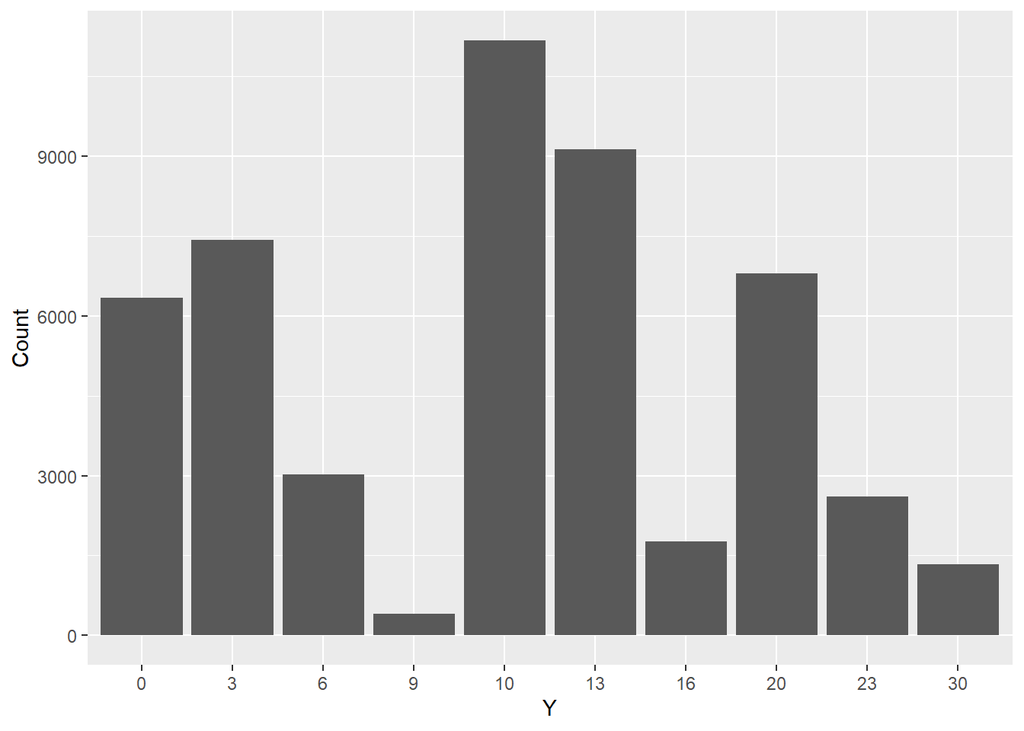

```r
sample_Yi %>% ggplot(aes(x = sample_Yi, y = Freq)) + ylab("Count") + xlab("Y") + geom_bar(stat = 'identity')
```

```r
#sample_Yi %>% ggplot(aes(x = sample_Yi, y = Freq)) + ylab("Count") + xlab("Y") + geom_col()

#sample_Yi %>% ggplot(aes(x = Y)) + ylab("Count") + xlab("Y") + geom_bar()
```

Step 3: Now, increase the values of n by setting n = 20, and repeat Step 1 and Step 2 to create a new bar plot for the samples of Y

```r
big_sample_Xi <- rmultinom(50000, 20, prob = c(0.5, 0.2, 0.3))
big_sample_Yi <- random_variables %*% big_sample_Xi
big_sample_Yi <- table(big_sample_Yi)

big_sample_Yi <- data.frame(big_sample_Yi)
big_sample_Yi %>% head(10)
```

```
##    big_sample_Yi Freq
## 1              9    6
## 2             12    4
## 3             13    1
## 4             15    6
## 5             16   21
## 6             18    8
## 7             19   34
## 8             20    3
## 9             21    4
## 10            22   64
```

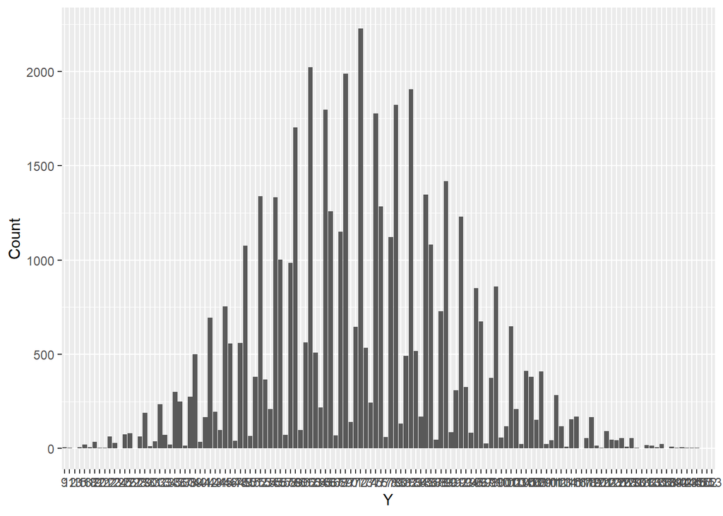

```r
#big_sample_Yi %>% ggplot(aes(x = big_sample_Yi)) + ylab("Count") + xlab("Y") + geom_bar()
big_sample_Yi %>% ggplot(aes(x = big_sample_Yi, y = Freq)) + ylab("Count") + xlab("Y") + geom_col()
```

Step 4: Next, increase n to 2000 and do the plot again.

```r
bigbig_sample_Xi <- rmultinom(50000, 2000, prob = c(0.5, 0.2, 0.3))
bigbig_sample_Yi <- random_variables %*% bigbig_sample_Xi
bigbig_sample_Yi <- table(bigbig_sample_Yi)

bigbig_sample_Yi <- data.frame(bigbig_sample_Yi)
bigbig_sample_Yi %>% head(10)
```

```
##    bigbig_sample_Yi Freq
## 1              6390    1
## 2              6416    1
## 3              6474    1
## 4              6476    1
## 5              6483    1
## 6              6484    1
## 7              6500    1
## 8              6531    1
## 9              6532    1
## 10             6535    1
```

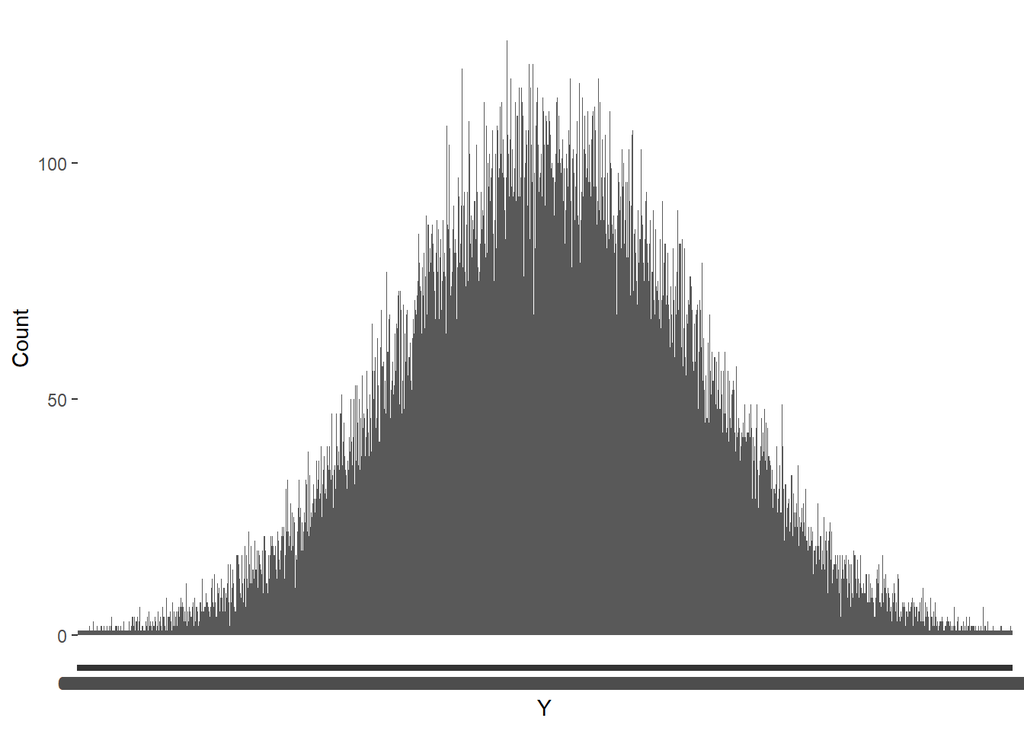

```r
bigbig_sample_Yi %>% ggplot(aes(x = bigbig_sample_Yi, y = Freq)) + ylab("Count") + xlab("Y") + geom_col()
```